# Model Evaluation (Notes)

Stat 253

# Learning Goals

- Practice building and evaluating linear regression models in RStudio working on:
  - Create and interpret residuals vs. fitted, residuals vs. predictor plots to identify improvements in modeling and address ethical concerns.
  - Calculate and interpret MSE, RMSE, MAE, and R-squared in a contextually meaningful way.
- Review some STAT 155 concepts and RStudio tools.
- Start using the **tidymodels** package to build and evaluate regression models.
- Get used to the course workflow, e.g. taking notes.

# Small Group Discussion: Video Recap

We are in the **regression** setting. We want to build a model of some **quantitative** output variable $y$ by some predictors $x$:

$$y = f(x) + \varepsilon$$

There are many regression tools that we might use to build this model. We’ll use a **linear regression** model which assumes that $y$ is a linear combination of the $x$’s:

$$y = \beta_0 + \beta_1 x_1 + \beta_2 x_2 + \cdots \beta_p x_p + \varepsilon$$

After *building* any model, it’s important to *evaluate* it: **Is our *regression model* a “*good*” model?**

1. Is the model wrong?
2. Is the model strong?
3. Does the model produce accurate predictions?
4. Is the model fair?

# Notes: R code

This section is for **future** reference. It is a summary of code you’ll learn below for building and evaluating regression models. Throughout, suppose we wish to build and evaluate a linear regression model of `y` vs `x1` and `x2` using our `sample_data`.

```r
# Load packages
library(tidyverse)
library(tidymodels)
```

**Building a linear regression model**

```r
# STEP 1: specify the type of model to build
lm_spec <- linear_reg() %>% # we want a linear regression model
  set_mode("regression") %>%  # this is a regression task (y is quantitative)
  set_engine("lm")# we'll estimate the model using the lm function

# STEP 2: estimate the specified model using sample data
model_estimate <- lm_spec %>%
  fit(y ~ x1 + x2, data = sample_data)

# Get the model coefficients
model_estimate %>%
  tidy()
```

**Obtaining predictions (& residuals) for each observation**

```r
# Obtain y predictions and residuals for each observation in our sample_data
# (We can replace sample_data with any data frame that includes y, x1, and x2)
model_estimate %>%
  augment(new_data = sample_data)

# Obtain y predictions (but not residuals) for some given x1, x2 values, when we haven't yet observed y
# (We can replace the data.frame with any data frame that includes x1 and x2)
model_estimate %>%
  augment(new_data = data.frame(x1 = ___, x2 = ___))

# Another approach using predict()
model_estimate %>%
  predict(new_data = data.frame(x1 = ___, x2 = ___))
```

**Evaluating the model**

```r
# Is it strong? (R^2)
model_estimate %>%
  glance()

# Does it produce accurate predictions? (MAE)
model_estimate %>%
  augment(new_data = sample_data) %>%
  mae(truth = y, estimate = .pred)

# Is it wrong? (residual plot)
model_estimate %>%
  augment(new_data = sample_data) %>%
  ggplot(aes(x = .pred, y = .resid)) +
geom_point() +
geom_hline(yintercept = 0)
```

# Exercises

Capital Bikeshare provides a bike-sharing service in the Washington DC area. Customers can pick up and drop off bikes at any station around the city. Of primary interest to the company is:

**How many registered riders can we expect today?**

To this end, you will build, evaluate, and compare 2 different **linear regression models** of ridership using the following Capital Bikeshare dataset (originally from the UCI Machine Learning Repository):

```r
# Load packages we'll need to wrangle and plot the data
library(tidyverse)

# Load the data
bikes <- read.csv("https://bcheggeseth.github.io/253_spring_2024/data/bike_share.csv")

# Only keep / select some variables
# And round some variables (just for our demo purposes)
bikes <- bikes %>%
  rename(rides = riders_registered, temp = temp_feel) %>%
  mutate(windspeed = round(windspeed), temp = round(temp)) %>%
  select(rides, windspeed, temp, weekend)
```

```r
# Check out the dimensions
dim(bikes)
## [1] 731   4

# Check out the first 3 rows
head(bikes, 3)
##   rides windspeed temp weekend
## 1   654        11   65    TRUE
## 2   670        17   64    TRUE
## 3  1229        17   49   FALSE
```

This dataset contains the following information for a sample of different dates:

| variable | description |
| --- | --- |
| rides | count of daily rides by registered users |
| windspeed | wind speed in miles per hour |
| temp | what the temperature feels like in degrees Fahrenheit |
| weekend | whether or not it falls on a weekend |

## 1: Plot the relationships

We’ll consider two linear regression models of ridership:

`rides ~ windspeed + temp`  
`rides ~ windspeed + temp + weekend`

First, let’s *plot* these relationships. REMEMBER: Don’t write in any chunk with starter code. Copy, paste, and modify the code in the chunk below it.

```r
# Start small: rides vs temp
ggplot(___, aes(y = ___, x = ___)) +
  geom___()
```

```r
# rides vs temp & windspeed
ggplot(bikes, aes(y = ___, x = ___, ___ = windspeed)) +
  geom_point()
```

```r
# rides vs temp & windspeed & weekend
ggplot(bikes, aes(y = ___, x = ___, ___ = windspeed)) +
  geom_point() +
  facet_wrap(~ ___)
```

## 2: tidymodels STEP 1

We’ll build and evaluate our two models of ridership using the **tidymodels** package. This code is more complicated than the `lm()` function we used in STAT 155. BUT:

- **tidymodels** is part of the broader **tidyverse** (what we use to plot and wrangle data), thus the syntax is more consistent
- **tidymodels** generalizes to the other ML algorithms we’ll survey in this course, thus will eventually *minimize* the unique syntax we need to learn

```r
# Load package
library(tidymodels)
```

The first step is to **specify what type of model we want to build**. We’ll store this as `lm_spec`, our linear regression model (`lm`) specification (`spec`).

```r
lm_spec <- linear_reg() %>%   # we want a linear regression model
  set_mode("regression") %>%  # this is a regression task (y is quantitative)
  set_engine("lm")            # we'll estimate the model using the lm function
```

This code *specifies* but doesn’t *build* any model – we didn’t even give it any data or specify the variables of interest!

```r
# Check it out
lm_spec
## Linear Regression Model Specification (regression)
##
## Computational engine: lm
```

## 3: tidymodels STEP 2

We can now estimate or `fit` our two ridership models using the specified model structure (`lm_spec`) and our sample `bikes` data:

```r
# Fit bike_model_1
bike_model_1 <- lm_spec %>%
  fit(rides ~ windspeed + temp, data = bikes)

# Check out the coefficients
bike_model_1 %>%
  tidy()
## # A tibble: 3 × 5
##   term        estimate std.error statistic  p.value
##   <chr>          <dbl>     <dbl>     <dbl>    <dbl>
## 1 (Intercept)    -20.8    300.     -0.0694 9.45e- 1
## 2 windspeed      -36.1      9.42   -3.83   1.37e- 4
## 3 temp            55.4      3.33   16.6    7.58e-53
```

```r
# YOUR TURN
# Fit bike_model_2 & check out the coefficients
```

## 4: Is it fair?

Now, let’s *evaluate* our two models. First, do you have any concerns about the context in which the data were collected and analyzed? About the potential impact of this analysis?

## 5: Is it strong?

We can measure and compare the strength of these models using $R^2$, *the proportion of variability in our response variable that’s explained by the model*. Report which model is stronger and interpret its $R^2$.

```r
# Obtain R^2 for bike_model_1
bike_model_1 %>%
  glance()
## # A tibble: 1 × 12
##   r.squared adj.r.squared sigma statistic  p.value    df logLik    AIC    BIC
##       <dbl>         <dbl> <dbl>     <dbl>    <dbl> <dbl>  <dbl>  <dbl>  <dbl>
## 1     0.310         0.308 1298.      163. 2.44e-59     2 -6276. 12560. 12578.
## # ℹ 3 more variables: deviance <dbl>, df.residual <int>, nobs <int>
```

```r
# YOUR TURN
# Obtain R^2 for bike_model_2
```

## 6: Pause – predictions and residuals

Our next model evaluation questions will focus on the models’ predictions and prediction *errors*, or *residuals*. We can obtain this information by *augmenting* our models with our original `bikes` data. For example:

```r
# Calculate predicted ridership (.pred) & corresponding residuals (.resid) using bike_model_1
# Just look at first 6 days
bike_model_1 %>%
  augment(new_data = bikes) %>%
  head()
## # A tibble: 6 × 6
##   .pred .resid rides windspeed  temp weekend
##   <dbl>  <dbl> <int>     <dbl> <dbl> <lgl>
## 1 3183. -2529.   654        11    65 TRUE
## 2 2911. -2241.   670        17    64 TRUE
## 3 2080.  -851.  1229        17    49 FALSE
## 4 2407.  -953.  1454        11    51 FALSE
## 5 2446.  -928.  1518        13    53 FALSE
## 6 2699. -1181.  1518         6    53 FALSE
```

We can also predict outcomes for *new* observations using either `augment()` or `predict()`. Note the difference in the output:

```r
# Predict ridership on a 60 degree day with 20 mph winds
bike_model_1 %>%
  augment(new_data = data.frame(windspeed = 20, temp = 60))
## # A tibble: 1 × 3
##   .pred windspeed  temp
##   <dbl>     <dbl> <dbl>
## 1 2581.        20    60
```

```r
# Predict ridership on a 60 degree day with 20 mph winds
bike_model_1 %>%
  predict(new_data = data.frame(windspeed = 20, temp = 60))
## # A tibble: 1 × 1
##   .pred
##   <dbl>
## 1 2581.
```

## 7: Does it produce accurate predictions?

Recall that the **mean absolute error** (MAE) measures the typical prediction error. Specifically, it is the *mean* of the *absolute* values of the residual *errors* for the days in our dataset.

### a

Use the residuals to calculate the MAE for the 2 models. HINT: `abs()`

```r
# DON'T TYPE IN THIS CHUNK
# MAE for bike_model_1
bike_model_1 %>%
  augment(new_data = bikes) %>%
  summarize(mae = ___(___(___)))
```

```r
# MAE for bike_model_1
```

```r
# YOUR TURN: MAE for bike_model_2
```

### b

Doing the calculation from scratch helps solidify your understanding of how MAE is calculated, thus interpreted. Check your calculations using a shortcut function.

```r
# Calculate MAE for the first model
bike_model_1 %>%
  augment(new_data = bikes) %>%
  mae(truth = rides, estimate = .pred)
## # A tibble: 1 × 3
##   .metric .estimator .estimate
##   <chr>   <chr>          <dbl>
## 1 mae     standard       1080.
```

```r
# YOUR TURN
# Calculate MAE for the second model
```

### c

Which model has more accurate predictions?

Interpret the MAE for this model and comment on whether it’s “large” or “small”. NOTE: “large” or “small” is defined by the context (e.g. relative to the observed range of ridership, the consequences of a bad prediction, etc).

## 8: Is it wrong?

To determine whether the linear regression assumptions behind `bike_model_1` and `bike_model_2` are reasonable, we can review residual plots, i.e. plots of the residuals vs predictions for each observation in our dataset. Run the code below and summarize your assessment of whether our models are wrong. RECALL: We want the appoints to appear *random* and *centered around 0* across the entire range of the model / predictions.

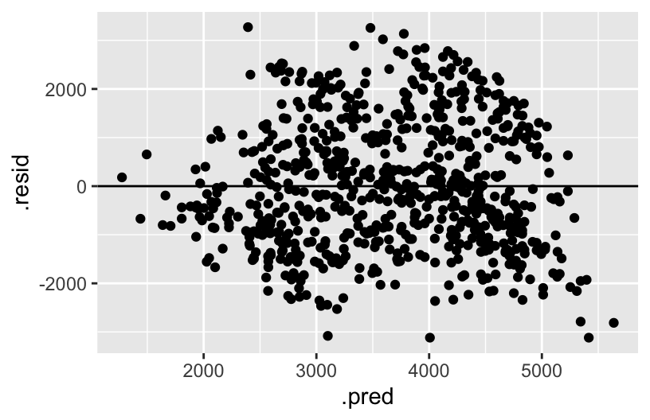

```r
# Residual plot for bike_model_1
bike_model_1 %>%
  augment(new_data = bikes) %>%
  ggplot(aes(x = .pred, y = .resid)) +
    geom_point() +
    geom_hline(yintercept = 0)
```

```r
# YOUR TURN
# Residual plot for bike_model_2
```

## 9: Art vs science

Inspecting residual plots is more art than science.[^1] It requires a lot of practice. Consider another example using simulated data. First, build a model that assumes all predictors are roughly linearly related:

```r
# Import data
simulated_data <- read.csv("https://ajohns24.github.io/data/simulated_data.csv")

# Model y by the 6 input variables
new_model <- lm_spec %>%
  fit(y ~ x1 + x2 + x3 + x4 + x5 + x6, simulated_data)
```

Next, check out a pairs plot. Is there anything here that makes you think that our model assumption is bad?

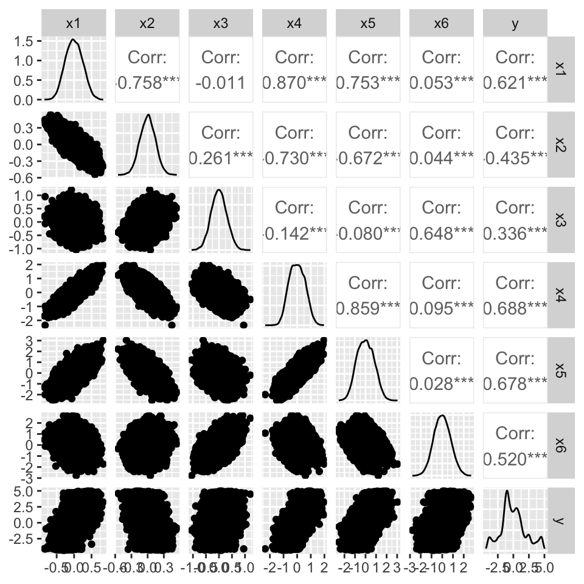

```r
library(GGally)
ggpairs(simulated_data)
```

Finally, check out a residual plot. Any concerns now?

```r
new_model %>%
  ___(new_data = ___) %>%
  ggplot(aes(x = ___, y = ___)) +
    geom_point(size = 0.1) +
    geom_hline(yintercept = 0)
```

## 10: Details – communication & code style

Communication is a key machine learning skill, including written summaries, presentations, and **code**. Just like an essay, code must have structure, signposts, and grammar that will make it easier for others to follow. The below code runs, but it is “bad code”.

- Fix this code and add **comments** so that it is easier for yourself and others to follow.
- Also pay attention to what this code *does*.

```r
bikes%>%group_by(weekend)%>%summarize(median(rides))
## # A tibble: 2 × 2
##   weekend `median(rides)`
##   <lgl>             <dbl>
## 1 FALSE              3848
## 2 TRUE               2955
```

```r
mynewdatasetissmallerthantheoriginal<-bikes%>%filter(rides<=700,weekend==FALSE,temp>60)
mynewdatasetissmallerthantheoriginal
##   rides windspeed temp weekend
## 1   577        18   67   FALSE
## 2   655        18   68   FALSE
## 3    20        24   72   FALSE
```

```r
mynewdatasetusescelsius<-bikes%>%mutate(temp=(temp-32)*5/9)
head(mynewdatasetusescelsius)
##   rides windspeed      temp weekend
## 1   654        11 18.333333    TRUE
## 2   670        17 17.777778    TRUE
## 3  1229        17  9.444444   FALSE
## 4  1454        11 10.555556   FALSE
## 5  1518        13 11.666667   FALSE
## 6  1518         6 11.666667   FALSE
```

## 11: STAT 155 Review – model interpretation & application

Let’s **interpret** and **apply** `bike_model_2`.

```r
___ %>%
  tidy()
```

### a

How can we interpret the `temp` coefficient?

- We expect roughly 54 more riders on warm days.
- We expect roughly 54 more riders per every 1 degree increase in temperature.
- When controlling for windspeed and weekend status, we expect roughly 54 more riders on warm days.
- When controlling for windspeed and weekend status, we expect roughly 54 more riders per every 1 degree increase in temperature.

### b

How can we interpret the `weekendTRUE` coefficient?

- We expect roughly 858 fewer riders on weekends.
- We expect roughly 858 fewer riders per every extra weekend.
- When controlling for windspeed and temperature, we expect roughly 858 fewer riders on weekends.
- When controlling for windspeed and temperature, we expect roughly 858 fewer riders per every extra weekend.

### c

Reproduce the predicted ridership and corresponding residual for day 1 from scratch (how were these calculated?!):

```r
bike_model_2 %>%
  ___(new_data = bikes) %>%
  head(1)
```

## 12: STAT 155 Review – data wrangling

Through the “Details: communication & code style” and elsewhere, you’ve reviewed the use of various `dplyr` data wrangling verbs: `filter()`, `mutate()`, `summarize()`, `group_by()`, `select()`, `arrange()`. Use these to complete the following tasks.

### a

Calculate the mean temperature across all days in the data set.

### b

Calculate the mean temperature on weekends vs weekdays.

### c

Print out the 3 days with the *highest* temperatures. HINT: `arrange()` or `arrange(desc())`

### d

Name and store a new data set which:

- only includes the days that fall on a weekend *and* have temps below 80 degrees
- has a new variable, `temp_above_freezing`, which calculates how far the temperature is above (or below) freezing (32 degrees F)
- only includes the `windspeed`, `temp`, and `temp_above_freezing` variables.

## 13: STAT 155 Review – plots

Construct plots of the following relationships:

```r
# rides vs temp
```

```r
# rides vs weekend
```

```r
# rides vs temp and weekend
```

## Done!

- Knit your notes.
- Check the solutions in the course website (Solution drop downs).

## Footnotes

[^1]: Stefanski, Leonard A. (2007). Residual (Sur)Realism. “The American Statistician,” 61, pp 163-177.